# Reading Matching Results

Module 2 · Day 2, Session 3: Two Case Studies

3ie

## What this session gives you

By the end of the next two hours you will be able to:

- Explain what a matching result means, in plain terms
- Find the one number in the table that is the programme’s effect
- Ask the single question that decides whether a matching result can be trusted
- Judge two real matching studies and say which one you believe more, and why
- Spot the mistakes AI makes when it reads a matching table

We will show and walk through some code so you get a feel for what happens behind the scenes. You will not have to write or run any code yourself.

## Where matching sits in the day

This morning gave you two tools, and each one needed a special ingredient.

**Difference-in-differences** needed a before and an after, and a comparison group already **moving in parallel**.

**Regression discontinuity** needed a **cut-off**, with businesses lined up on either side of it.

**Matching** needs neither.

No parallel trends, no threshold. Just rich data on **who each business is**.

That freedom is its appeal. It is also where the catch lives.

## The case at a glance

Programme

GreenWaste, offered to eligible businesses

Who enrolled

Eligible businesses in programme neighbourhoods

Comparison pool

Businesses that did not enrol, matched on their characteristics

Outcome

Waste management costs (AED)

What we know

Manager and deputy age and education, staff size, filtration, water treatment, area, distance to recycling

Decision rule

Scale up only if costs fall by at least 1,000 AED

# 1 · The trap 10 min

## A convincing comparison

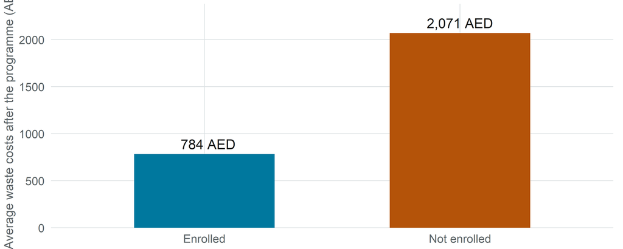

Businesses that enrolled spend far less than those that did not. Did the programme cause that whole gap?

## Why that gap is not the effect

The businesses that enrolled were **different from the start**. They were eligible for a reason: they already scored differently on the efficiency index, and they differ on size, ownership and management too.

Most of that raw gap is **who these businesses already were**, not what the programme did.

This is the same selection problem from this morning. Matching is one way to try to fix it: instead of comparing the two whole groups, compare each enrolled business with one that looks just like it.

# 2 · The idea, in plain terms 15 min

## Matching in one sentence

For each business that received the programme, find a business as **similar as possible** that did not, then compare the two.

Do that for every enrolled business, and you have built a comparison group that looks like the programme group in every way you measured.

The difference in costs between the matched groups is the estimated effect.

## When is matching the right tool?

**Use it when:**

- Assignment was **not** random
- There is **no** clean eligibility cut-off to exploit
- But you have **rich data** on the characteristics that drove who took part
- And there are enough similar untreated units to draw twins from

**You see this shape often:**

- A voluntary programme people opt into
- A service take-up you could not randomise
- Comparing adopters with similar non-adopters
- Any “we have good baseline data” evaluation

Matching is the workhorse for observational data: no experiment, no threshold, but a lot known about each unit.

## Your turn: find the twins

Match each enrolled business to the not-enrolled business it most resembles, then read off the cost difference.

| Enrolled business | Not-enrolled candidates |
| --- | --- |
| A: manager 45, small, 12,000 cost | 1: manager 39, large |
| B: manager 38, large, 9,000 cost | 2: manager 46, small |
| C: manager 52, small, 14,000 cost | 3: manager 51, small |

Which candidate is the right twin for each enrolled business?

Match on **who they are**, not on their cost. Then the cost gap between the pairs is your rough estimate.

Ninety seconds. Notice what you are doing: you are throwing away the candidates that do not resemble anyone.

## Before matching: two different crowds

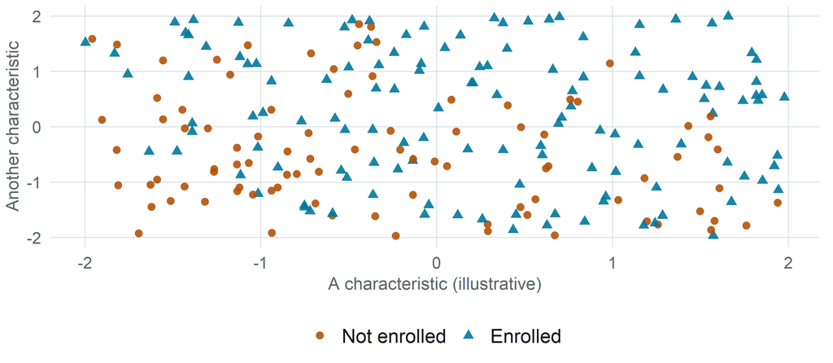

The two groups sit in different parts of the picture. Matching keeps only the region where they **overlap**, and pairs like with like inside it.

# Break 5 min

## Five minutes

We have the idea: pair each enrolled business with a similar one that did not enrol, and compare.

After the break we open the actual output an evaluator would hand you, and find the one number that is the effect.

# 3 · Reading the output 20 min

## Three steps behind the table

```r
# Step 1. Estimate how likely each business
#   was to enrol, from what we know about it.
# Step 2. Keep only businesses that have a
#   genuine match on the other side, and pair
#   each enrolled one with its closest twin.
psm <- matchit(
  enrolled ~ age_manager_0 + educ_manager_0 +
    staff_size_0 + foreign_owned_0 +
    business_area_0,          # and a few more
  method = "nearest", estimand = "ATT")

# Step 3. Compare the matched groups' costs.
out <- lm_robust(
  waste_management_costs_1 ~ enrolled,
  data = match.data(psm),
  clusters = neighborhood_identifier)
```

- **Step 1** turns many characteristics into a single “likelihood of enrolling” score.
- **Step 2** throws out businesses with no counterpart, then pairs the rest.
- **Step 3** is the comparison you would have wanted all along, now between look-alike groups.

## Did we find real twins? Common support

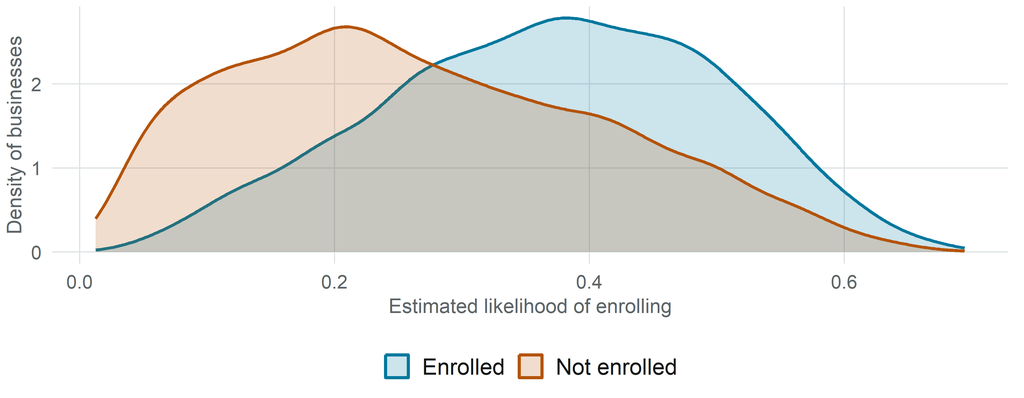

Matching can only work where the two curves **overlap**. Where one group has no counterpart, those businesses are set aside, and the result stops applying to them.

## Did matching work? Balance

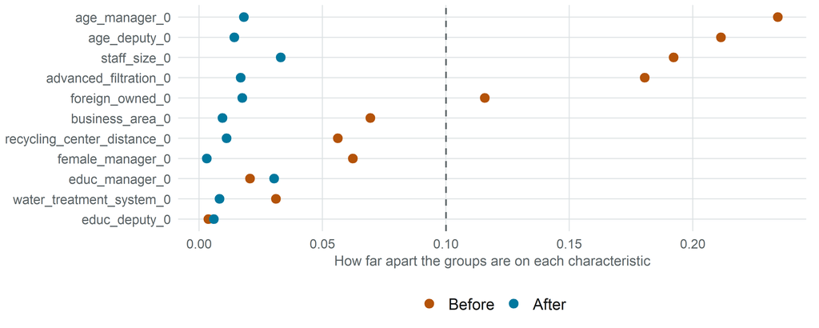

Each dot is one characteristic. Matching pulls the gaps toward zero: after matching, the two groups look alike on everything we fed in.

## The number that answers your question

-967 AED

`enrolled`: the cost difference between the matched groups

This is the comparison you wanted: like against like, on everything measured. It is your rough twin exercise, done for every enrolled business at once.

## How sure are we?

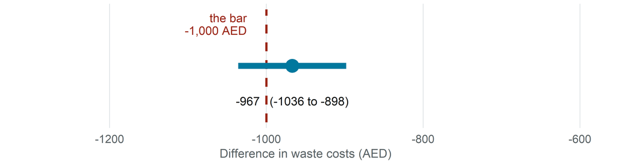

The estimate is **statistically significant**: we are confident it is not zero. Its best estimate sits **just short of the 1,000 AED bar** you set. Significant is not the same as sufficient.

# 4 · A second way: matching in bins 8 min

## Coarsened exact matching: the idea

Propensity matching scores each business, then pairs on the score. There is a second common approach that is even easier to picture:

Sort businesses into **bins** (a range of ages, a range of sizes), then compare enrolled and not-enrolled businesses **inside the same bin**.

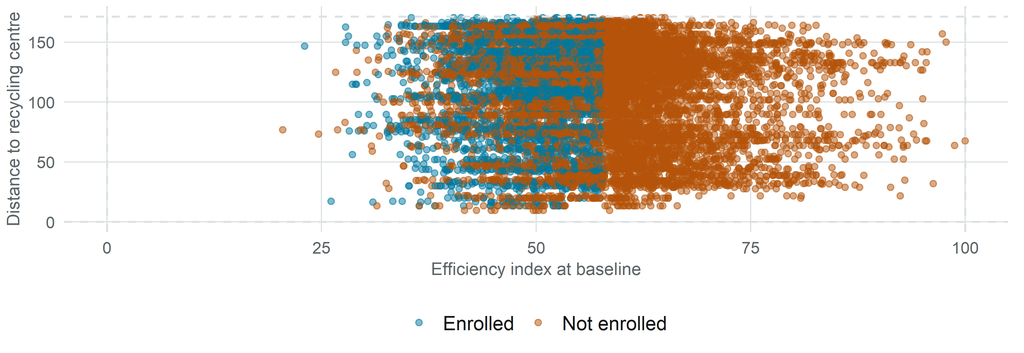

## What it keeps, and what it drops

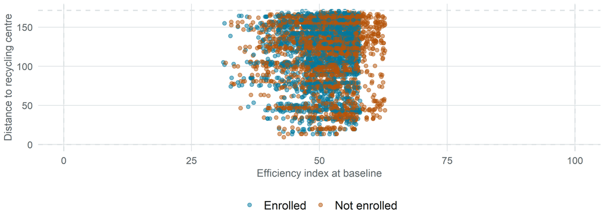

Only the boxes that held **both** kinds of business survive. The rest are dropped. Different recipe, same discipline, and it lands at a similar answer to the score-based method.

# 5 · The one question 12 min

## What matching rests on

Difference-in-differences rested on parallel trends. Regression discontinuity rested on a clean cut-off. Matching rests on something plainer, and harder:

Everything that made a business likely to enrol, **and** likely to have different costs anyway, was **measured** and matched on.

Balance proves the groups are alike on what we measured. It can say nothing about what we did not.

## The question to put to any matching study

“What else might be different about these two groups that you could not measure?”

For GreenWaste, think about what is **not** on the “what we know” list: the drive of the owner, the quality of management, an expansion already planned, a supplier relationship. Any of these could make a business both more likely to enrol **and** lower its costs on its own.

Matching cannot touch them. Balance will still look perfect.

## The same firms, a different answer

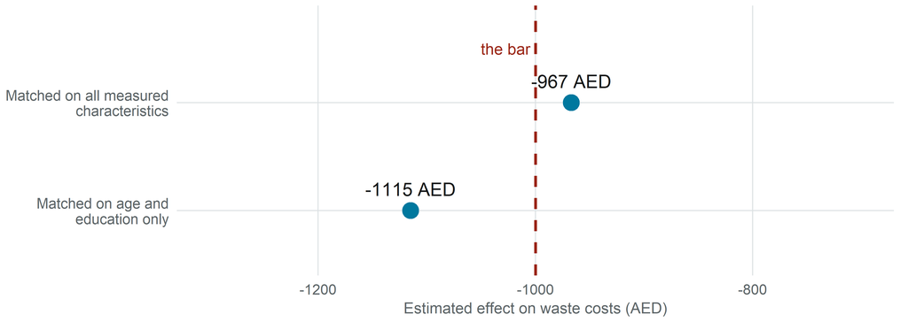

Same businesses, same method. Match on a thin set of characteristics and the estimate lands on **one side** of the bar; match on the full set and it lands on the **other**. The answer depends on what you chose to feed in.

# 6 · AI Snapshot 20 min

## We gave AI the matching table and asked it to explain

**Prompt:** *“Explain these results.”*

The analysis uses propensity score matching to evaluate the GreenWaste Program. After matching, the treated and comparison businesses are well balanced on all characteristics, so the estimate is free of selection bias and can be read as the causal effect.

Because the effect is statistically significant, the programme should be scaled up nationally.

## What it got wrong

**1 · It treated balance as proof of no bias**

Balance is on the **measured** characteristics only. Matching cannot remove differences it could not see, and this sentence quietly claims it did.

**2 · It invented a robustness check**

**3 · It ignored your decision rule**

**4 · It invented precision**

Notice: the answer was fluent, confident and correctly formatted. Nothing in its tone marks the true sentences apart from the invented ones.

## The same table, a better prompt

### What people type

*“Explain these results.”*

- No decision rule
- No hint that this is observational
- No invitation to flag what matching cannot fix
- Every gap filled with a confident guess

### What to type instead

*I am a commissioner, not an analyst. Below is a propensity-score matching table from a waste programme evaluation. This is observational: businesses chose to enrol. Our decision rule: costs must fall by at least 1,000 AED to justify national scale-up.*

*Before answering, ask me what characteristics were matched on and what was not measured.*

*Then: (1) which single number is the effect; (2) does it meet our rule; (3) what selection could matching NOT have fixed here; (4) do not claim robustness to unobserved factors.*

## Your turn

In your groups, using the table on your handout:

1. Run the **short prompt**. Read what you get.
2. Run the **full prompt card**. Answer the questions it asks you.
3. Compare: what did the second answer add, remove, or hedge, especially about **what was not measured**?
4. Paste the second answer into a **fresh chat** and ask: *“Review this interpretation for errors and overstatement.”*

Step 4 matters. A second, clean conversation catches what the first one is already committed to.

## Debrief

- Did AI treat **balance** as proof that bias was gone?
- Did it **invent** a robustness check, a p-value, or a sample size?
- Did it check the result against **your 1,000 AED rule**?
- Did the second chat catch what the first missed?

Two habits, every time: tell the AI your decision rule and that the data is observational, and make it ask you questions before it answers.

# 7 · Two case studies, side by side 16 min

## Case 1: GreenWaste, a clean match

Data

Rich baseline on every business

Overlap

Good: most enrolled firms had real twins

Balance

Achieved on all measured characteristics

A well-executed matching study. The mechanics all check out.

The one caveat is the one that never goes away: it holds **only** if nothing important was left unmeasured.

Programme

Outcome

Matched on

The problem

Estimate

[figure not shown]

When the curves barely overlap, most enrolled units have **no real twin**. They get dropped, and the result quietly narrows to the few who happened to have a match. Who is the finding still about?

In your groups:

1. Which case gives you **more confidence**, and why?
2. What would you ask **Case 2’s** evaluator that Case 1 does not raise?
3. Would you act on Case 2, act with caveats, or send it back?

Verdict round: hands, not discussion. Name the one question that decided it for you.

# 8 · Closing 6 min

## Three questions to ask any evaluator presenting matching

**1 · “What did you match on, and what could you not measure?”**

The honest answer names the characteristics left out and why they might matter.

**2 · “How many treated units had a good match, and who got dropped?”**

Poor overlap narrows who the result is about, often without saying so.

**3 · “Does this clear the bar we set, and does the answer hold if you change what you matched on?”**

Significant is not sufficient, and a result that flips with the variable list is not settled.

## Where this sits: Day 2 scoreboard

| Method | Estimate | Verdict |
| --- | --- | --- |
| Difference-in-differences | -816 AED | Below the bar: do not scale |
| Regression discontinuity | -905 AED | Below the bar: do not scale |
| Matching | -967 AED | Below the bar: do not scale |
| Randomised trial | -1,014 AED (Module 1) | Above the bar: scale up |

Three methods now say do not scale. The randomised trial said scale up. Same programme, same data, different answers.

## Same programme, four numbers, two answers

The methods do not disagree because one is wrong. They answer **slightly different questions about slightly different businesses**:

- Matching and DiD compare enrolled firms with non-enrolled ones who differ in ways we may not see
- RDD speaks only to firms near the cut-off
- The randomised trial removed selection entirely, and measured a genuine average

The lesson is not “pick the method you like”. It is: know which question each number answers before you let it decide anything.

## Next: was it worth it?

**Cost analysis**: an effect is only half the decision. Tomorrow we put the programme’s impact next to what it cost, and ask whether the money was well spent.

You now have four ways to read an impact. The next question is what any impact is worth against its price.